# NHS R Data Visualisation Library

NHS England Regional Collaboration utilising the foundations of a GGplot library created by Mike Perham

17/05/2024

This library has been created to enable users to view examples of data visualisations utilising the NHS themes, using NHS public data sets. Users can load the required packages and create the sample data sets, and then choose which data visualisations they would like to run in their own environment.

The foundations of this library are sourced from a GGplot guide by Mike Perham. This has been expanded as a proof of concept for working collaboratively over regions to input and build upon, becoming the R Data Viz Library.

For more information about each data visualisation type, the below are recommended to review:

### The Data Visualisation Catalogue: https://datavizcatalogue.com/index.html

### The R Graph Gallery: https://r-graph-gallery.com/

### Top 50 GGplot2 Visualisations: https://r-statistics.co/Top50-Ggplot2-Visualizations-MasterList-R-Code.html

# Install/load required packages

```r
if (!require("pacman")) install.packages("pacman"); library(pacman)

pacman::p_load(Rcpp, tidyverse,dplyr,tidyr,
               ggplot2,ggthemes,ggtext,scales,
               png,ggalt,NHSRdatasets,onsr,shinycssloaders, plotly, FunnelPlotR)

# install.packages('devtools')
#devtools::install_github('nhs-r-community/NHSRtheme')
# install.packages("remotes")
remotes::install_github("rOpenSci/fingertipsR",
                        build_vignettes = TRUE,
                        dependencies = "suggests",
                        build = F)
devtools::install_github("ricardo-bion/ggradar")
#https://github.com/ricardo-bion/ggradar
```

# Load sample data

All of the examples in this document use A&E dummy data from the NHSRdatasets package for NHS reporting, fingertips data for Public Health and ONS data for population data. These give us broad datasets that can be used for different data visualisation types.

More information on these packages can be found here:

### NHSRdatasets:

https://github.com/nhs-r-community/NHSRdatasets

https://nhs-r-community.github.io/NHSRdatasets/

```r
#Load initial dataset and clean up
Attends <- NHSRdatasets::ae_attendances %>%
  filter(org_code == "RXQ"|org_code=="RTH"|org_code=="RHW"|
           org_code == "RTK"|org_code == "RA2") %>%
  filter(type ==1) %>%
  select(-c(3,5))
```

### Fingertips:

https://github.com/ropensci/fingertipsR

The below gets population by sex.

```r
# Load fingertipsR package
library(fingertipsR)

# Get available profiles in fingertips
profiles_data <- profiles()
print(profiles_data)

# Find profiles related to population
population_profiles <- profiles_data %>%
  filter(grepl("population", ProfileName, ignore.case = TRUE))
print(population_profiles)

# Search for indicators related to population structure, DomainID was found by viewing the population_profiles and selecting a DomainID
population_indicators <- indicator_metadata(DomainID = "1938133081") #Replace with DomainID from above

# Get the relevant indicator of the measure from your list of population_indicators
indicator_id <- 92708  # Replace with the actual indicator ID from the results above

#Get list of area types
area_types_data <- area_types()

# Get the data for the specific indicator
population_data <- fingertips_data(IndicatorID = indicator_id,AreaTypeID = "15") #Note for Area Types you can select all, but it will take a long time. 15 is England.

# Filter data to include only relevant columns and non-NA values
population_data_filtered <- population_data %>%
  filter(!is.na(Age), !is.na(Value)) %>%
  select(AreaName, Sex, Age, Value)

# Adjust the values for plotting (male values negative for pyramid structure)
population_data_filtered <- population_data_filtered %>%
  mutate(Value = ifelse(Sex == "Male", -Value, Value)) %>%
  filter(Age != "All ages") %>%
  filter(Sex != "Persons")

# Convert the Age column to a factor and specify the levels in the desired order
population_data_filtered$Age <- factor(population_data_filtered$Age, levels = c("0-4 yrs", "5-9 yrs", "10-14 yrs", "15-19 yrs", "20-24 yrs", "25-29 yrs", "30-34 yrs", "35-39 yrs", "40-44 yrs", "45-49 yrs", "50-54 yrs", "55-59 yrs", "60-64 yrs", "65-69 yrs", "70-74 yrs", "75-79 yrs", "80-84 yrs", "85-89 yrs","90+ yrs"))
```

### ONS:

https://medium.com/@VickyCrockett1/how-do-you-get-data-into-r-from-the-ons-c860043fef8c

# NHSR Theme

All of the examples in this document use dummy data from the NHSRdatasets package (more information on this package can be found here: https://github.com/nhs-r-community/NHSRtheme). As the package is not in CRAN, you need to use devtools to load the package from github.

```
## Using GitHub PAT from the git credential store.
```

```
## Skipping install of 'NHSRtheme' from a github remote, the SHA1 (48293555) has not changed since last install.
##   Use `force = TRUE` to force installation
```

```
##   DarkBlue       Blue BrightBlue  LightBlue   AquaBlue      Black   DarkGrey
##  "#003087"  "#005EB8"  "#0072CE"  "#41B6E6"  "#00A9CE"  "#231f20"  "#425563"
##    MidGrey   PaleGrey  DarkGreen      Green LightGreen  AquaGreen     Purple
##  "#768692"  "#E8EDEE"  "#006747"  "#009639"  "#78BE20"  "#00A499"  "#330072"
##   DarkPink       Pink    DarkRed        Red     Orange WarmYellow     Yellow
##  "#7C2855"  "#AE2573"  "#8A1538"  "#DA291C"  "#ED8B00"  "#FFB81C"  "#FAE100"
```

# Data Over Time

## Basic line chart

### ggplot

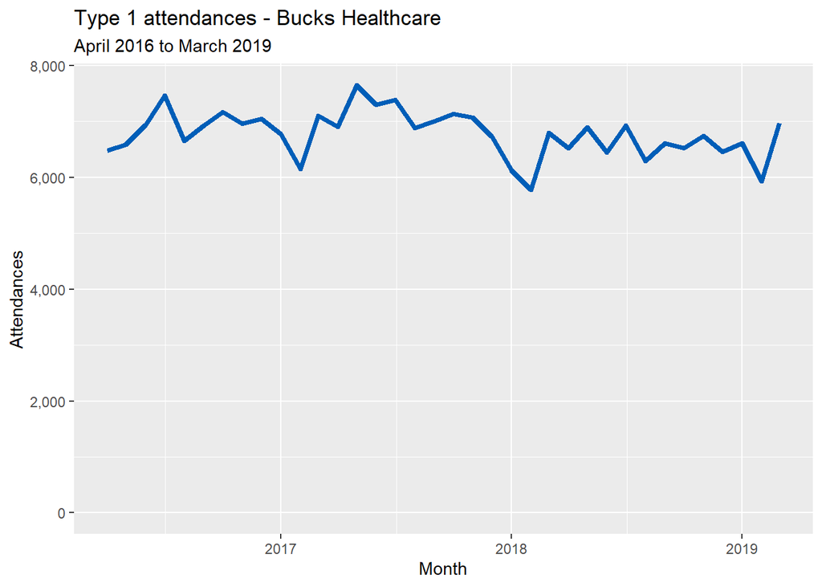

```r
#Filter initial dataset
line_df <- Attends %>%
  filter(org_code=="RXQ")

#Make plot
ggplot(line_df, aes(x = period, y = attendances)) +
  geom_line(colour = "#005EB8", size = 1.5) +
  scale_y_continuous(labels = comma) +
  labs(title="Type 1 attendances - Bucks Healthcare",
       subtitle = "April 2016 to March 2019",
       y = "Attendances",
       x = "Month") +
  expand_limits(y = 0)
```

## Multiple line chart

### ggplot

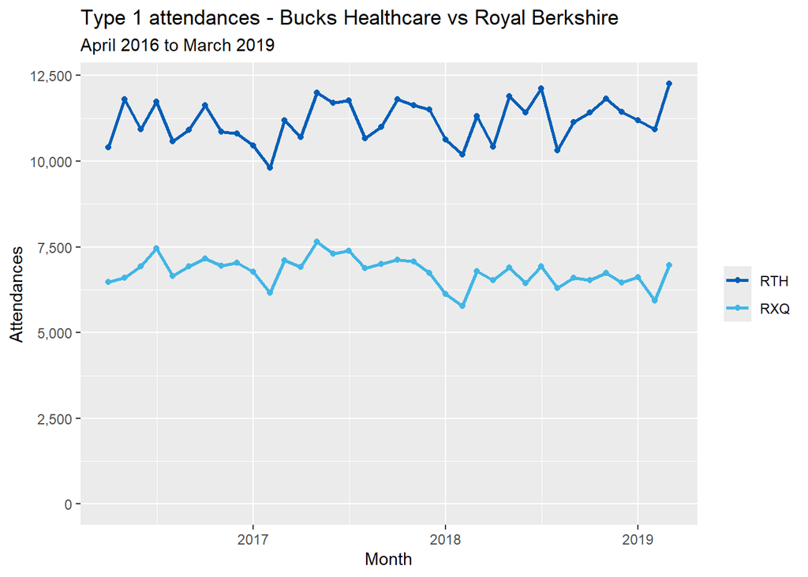

```r
#Filter initial dataset
multiple_line_df <- Attends %>%
  filter(org_code == "RXQ" | org_code=="RTH")

#Make plot
ggplot(multiple_line_df,
         aes(x = period, y = attendances, colour = org_code)) +
  geom_line(size = 1) +
  geom_point() +
  scale_colour_manual(values = c("#005EB8", "#41B6E6")) +
  scale_y_continuous(labels = comma) +
  labs(
    title = "Type 1 attendances - Bucks Healthcare vs Royal Berkshire",
    subtitle = "April 2016 to March 2019",
    y = "Attendances",
    x = "Month"
  ) +
  expand_limits(y = 0) +
  theme(legend.title = element_blank())
```

# Comparisons

## Simple bar chart

### ggplot

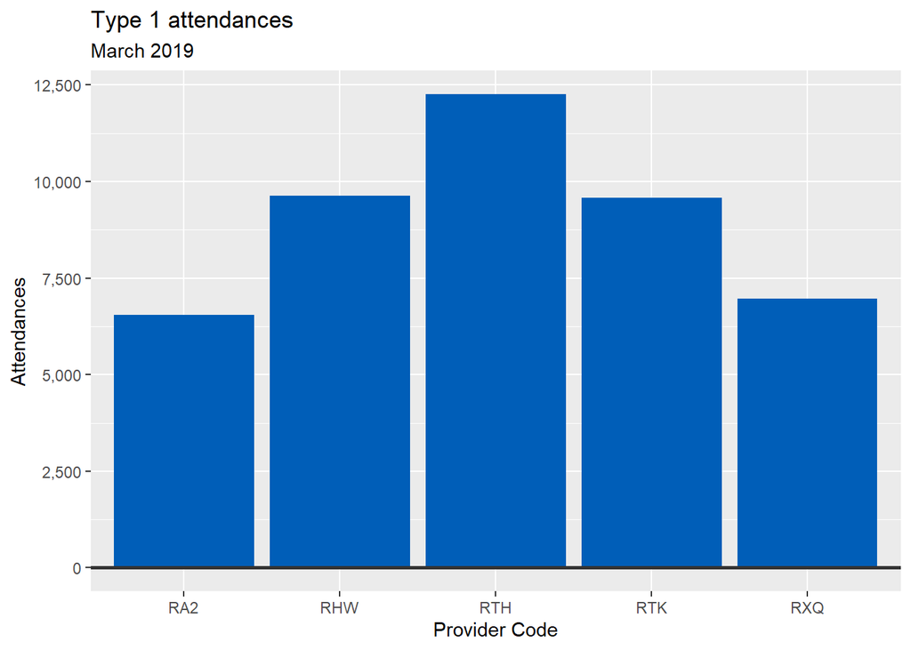

```r
#Filter initial dataset
bar_df <- Attends %>%
  filter(period == "2019-03-01")

#Make plot
bar <- ggplot(bar_df, aes(x = org_code, y = attendances)) +
  geom_bar(stat = "identity",
           position = "identity",
           fill = "#005EB8") +
  geom_hline(yintercept = 0,
             size = 1,
             colour = "#333333") +
  scale_y_continuous(labels = comma) +
  labs(
    title = "Type 1 attendances",
    subtitle = "March 2019",
    y = "Attendances",
    x = "Provider Code"
  )

plot(bar)
```

**Add labels**

The code below adds labels to your simple bar chart.

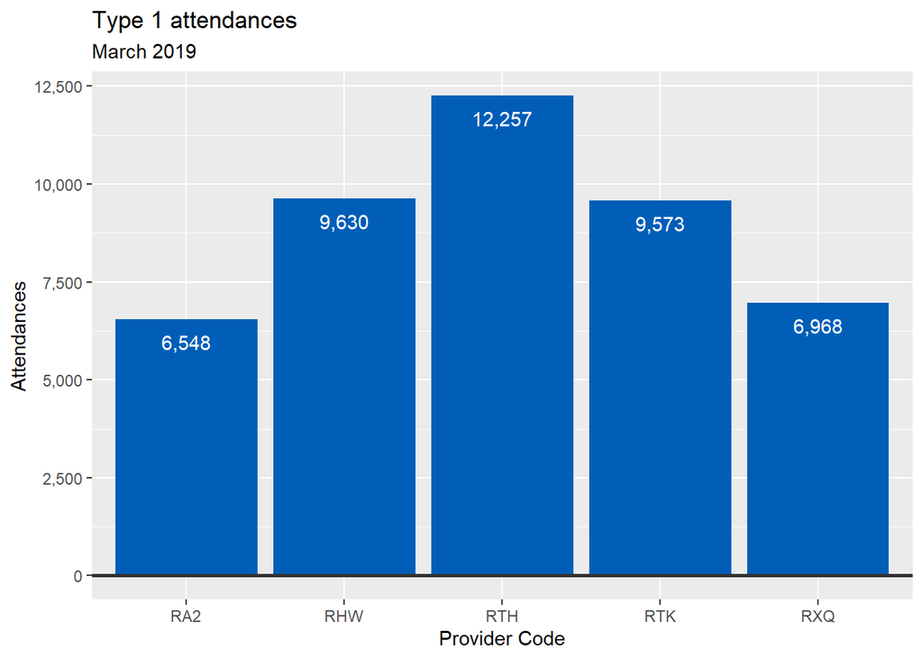

```r
#Filter initial dataset
bar + geom_text(aes(label = scales::comma(attendances)), vjust =2, color= "White")
```

## Grouped bar chart

### ggplot

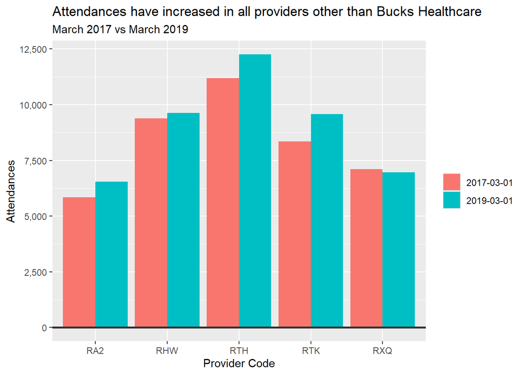

```r
#Filter initial dataset
grouped_bar_df <- Attends %>%
  filter(period == "2017-03-01" | period == "2019-03-01") %>%
  select(c(1:3))

#Make plot
ggplot(grouped_bar_df,
       aes(
         x = org_code,
         y = attendances,
         fill = as.factor(period)
       )) +
  geom_bar(stat = "identity", position = "dodge") +
  geom_hline(yintercept = 0,
             size = 1,
             colour = "#333333") +
  scale_y_continuous(labels = comma) +
  #NHSRtheme::scale_fill_nhs('blues')+
  labs(
    title = "Attendances have increased in all providers other than Bucks Healthcare",
    subtitle = "March 2017 vs March 2019",
    y = "Attendances",
    x = "Provider Code"
  ) +
  theme(legend.title = element_blank())
```

## Stacked bar chart

### ggplot

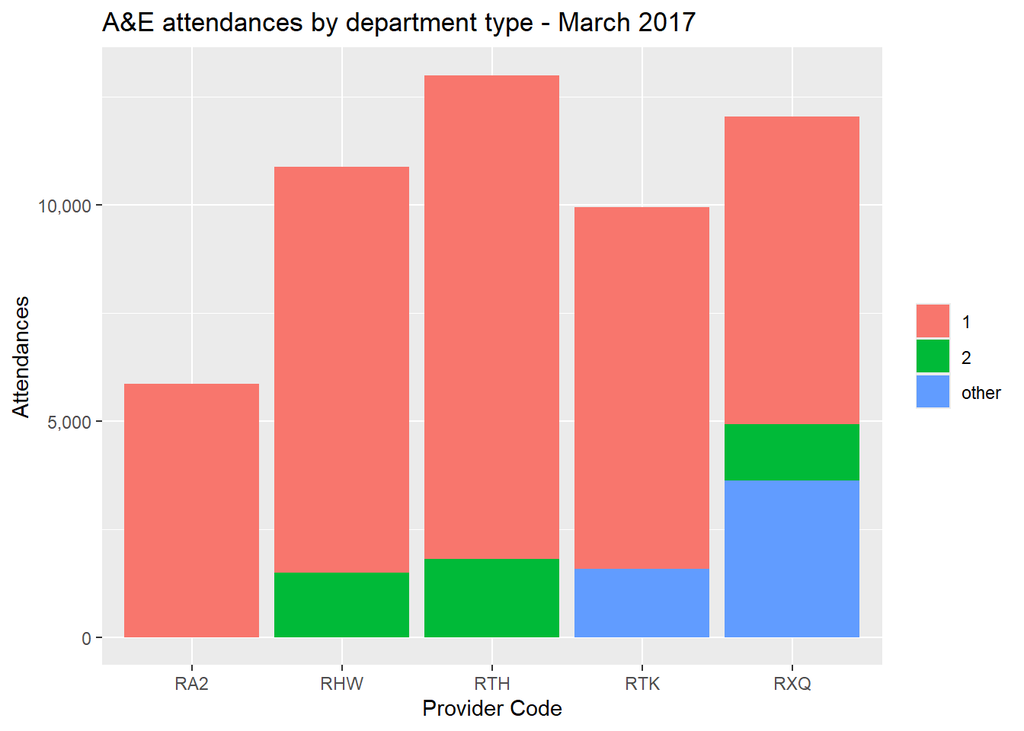

```r
AttendsAll <- NHSRdatasets::ae_attendances %>%
  filter(
    org_code == "RXQ" | org_code == "RTH" | org_code == "RHW" |
      org_code == "RTK" | org_code == "RA2"
  ) %>%
  filter(period == '2017-03-01')

ggplot(AttendsAll, aes(fill = type, y = attendances, x = org_code)) +
  geom_bar(position = "stack", stat = "identity") +
  scale_y_continuous(labels = comma) +
  labs(title = "A&E attendances by department type - March 2017",
       y = "Attendances",
       x = "Provider Code") +
  theme(legend.title = element_blank())
```

## Percent stacked bar chart

### ggplot

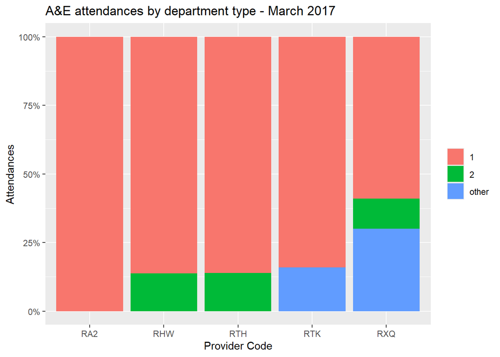

```r
AttendsAll <- NHSRdatasets::ae_attendances %>%
  filter(
    org_code == "RXQ" | org_code == "RTH" | org_code == "RHW" |
      org_code == "RTK" | org_code == "RA2"
  ) %>%
  filter(period == '2017-03-01')

ggplot(AttendsAll, aes(fill = type, y = attendances, x = org_code)) +
  geom_bar(position = "fill", stat = "identity") +
  scale_y_continuous(labels = percent) +
  labs(title = "A&E attendances by department type - March 2017",
       y = "Attendances",
       x = "Provider Code") +
  theme(legend.title = element_blank())
```

## Bubble chart

### ggplot

```r
#For this example we are filtering on 5 organisations, type 1 activity & excluding column 3 from the dataframe.
Attends <- NHSRdatasets::ae_attendances %>%
  filter(org_code == "RXQ"|org_code=="RTH"|org_code=="RHW"|
           org_code == "RTK"|org_code == "RA2")

  # Summarise data for type 1 attendances
  type_1_summary <- Attends %>%
  filter(type == 1) %>%
  group_by(org_code, period) %>%
  summarise(type_1_attendances = sum(attendances, na.rm = TRUE)) %>%
  ungroup()
# Summarise data for non-type 1 attendances
type_other_summary <- Attends %>%
  filter(type == 3|type== 2) %>%
  group_by(org_code, period) %>%
  summarise(type_other_attendances = sum(attendances, na.rm = TRUE)) %>%
  ungroup()
# Summarise total attendances and total admissions
total_summary <- Attends %>%
  group_by(org_code, period) %>%
  summarise(
    total_attendances = sum(attendances, na.rm = TRUE),
    total_breaches = sum(breaches, na.rm = TRUE),
    total_admissions = sum(admissions, na.rm = TRUE)
  ) %>%
  ungroup()
```

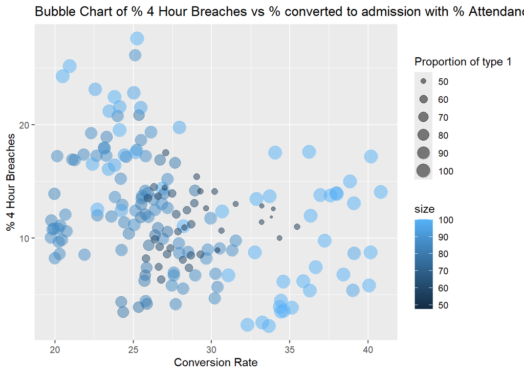

```r
# Merge the summaries into a single data frame
final_summary <- total_summary %>%
  left_join(type_1_summary, by = c("org_code", "period")) %>%
  left_join(type_other_summary, by = c("org_code", "period"))

# Replace NA values with 0 for type_1_attendances and type_3_attendances
final_summary <- final_summary %>%
  mutate(
    type_1_attendances = replace_na(type_1_attendances, 0),
    type_other_attendances = replace_na(type_other_attendances, 0)
  )

# Add percentage columns
final_summary <- final_summary %>%
  mutate(
    perc_admissions_attendances = (total_admissions / total_attendances) * 100,
    perc_type1_attendances_total = (type_1_attendances / total_attendances) * 100,
    perc_breaches_attendances = (total_breaches / total_attendances) * 100
  )

# Filter initial dataset
bubble_df <- final_summary

# Calculate size for bubble chart (proportional to type 1 attendances)
bubble_df <- bubble_df %>%
  mutate(size = perc_type1_attendances_total / max(perc_type1_attendances_total) * 100)

# Create bubble chart
ggplot(bubble_df, aes(x = perc_admissions_attendances, y = perc_breaches_attendances, size = size, color = size)) +
  geom_point(alpha = 0.5) +
  scale_size_continuous(name = "Proportion of type 1") +
  #NHSRtheme::scale_fill_nhs('blues', name = "Proportion of type 1") +
  labs(title = "Bubble Chart of % 4 Hour Breaches vs % converted to admission with % Attendances Type 1 Size",
       x = "Conversion Rate", y = "% 4 Hour Breaches") +
  theme(legend.position = "right")
```

## Population Pyramid chart

### ggplot

```r
# Plot the population pyramid
ggplot(population_data_filtered, aes(x = Age, y = Value, fill = Sex)) +
  geom_bar(stat = "identity", position = "identity") +
  coord_flip() +
  scale_y_continuous(labels = function(x) comma(abs(x))) +
  labs(title = "Population Age Profile by Gender",
       x = "Age Group",
       y = "Population Count",
       fill = "Gender") +
  NHSRtheme::scale_fill_nhs("blues")
```

[output not shown]

## Radar chart

```r
# Create Example dataset
data <- tibble::tribble(
  ~group, ~Trauma_and_Orthopaedics, ~General_Surgery, ~Gynaecology, ~Ophthalmology, ~Dermatology,
  "Trust 1", 0.8, 0.9, 0.7, 0.6, 0.9,
  "Trust 2", 0.6, 0.7, 0.8, 0.7, 0.6,
  "Trust 3", 0.7, 0.8, 0.9, 0.8, 0.7
)

# Create the radar chart
ggradar(data,
        values.radar = c("0%", "50%", "100%"), #Sets labels for min, min & max grid lines
        grid.min = 0, grid.mid = 0.5, grid.max = 1, #Defines the values for the grid lines
        group.line.width = 2, #Changes the line width of plotted line
        group.point.size = 3, #Changes the point size of plotted line
        group.colours = c("#00AFBB", "#E7B800", "#FC4E07"), #Colour for plotted lines based on group
        background.circle.colour = "white", #Plot background colour
        gridline.mid.colour = "grey", #Colour of gridlines
        legend.position = "bottom") #Position can be
```

[output not shown]

## Radial Column chart

### ggplot

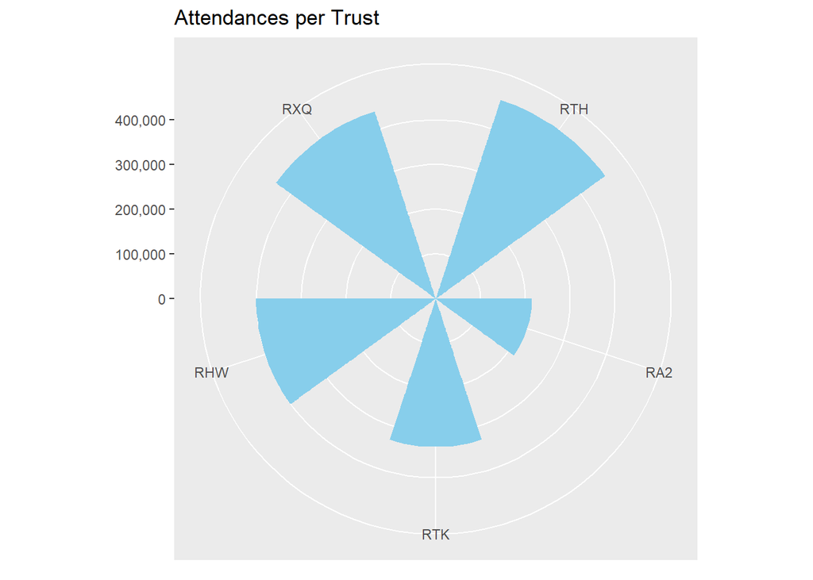

```r
# Create a radial column chart
ggplot(Attends, aes(x = reorder(org_code, -attendances), y = attendances)) +
  geom_col(width = 0.5, fill = "skyblue") +
  coord_polar(start = 0) +
   #NHSRtheme::scale_fill_nhs("blues") +
  scale_y_continuous(labels = function(x) comma(abs(x))) +
  labs(title = "Attendances per Trust",
       x = NULL, y = NULL)
```